# Practical Machine Learning: Course Project

# November 23, 2014

## Downloading data

The data for this report you can download of the following links:

https://d396qusza40orc.cloudfront.net/predmachlearn/pml-training.csv

https://d396qusza40orc.cloudfront.net/predmachlearn/pml-testing.csv

Firstly I create a folder to save the data files, second I download the training and testing data and finally I upload the data in R (format csv).

### Training data

```r
if(!file.exists("./cproject")) {dir.create("./cproject")}
training <- "https://d396qusza40orc.cloudfront.net/predmachlearn/pml-training.csv"
download.file(training, destfile = "./cproject/pml-training.csv", method = "curl")
dtraining <- read.csv("./cproject/pml-training.csv", na.strings = c("NA", ""))
```

### Testing data

```r
testing <- "https://d396qusza40orc.cloudfront.net/predmachlearn/pml-testing.csv"
download.file(testing, destfile = "./cproject/pml-testing.csv", method = "curl")
dtesting <- read.csv("./cproject/pml-testing.csv", na.strings = c("NA", ""))
```

### Uploading packages

I will use the packages caret and randonForest to estimate the models.

```r
#install.packages("caret")
library(caret)
#install.packages("randomForest")
library(randomForest)
```

## Cleaning data

The training and testing data have several variables with NA values, the first step is find the columns with NA values.

```r
table(colSums(is.na(dtraining)))
```

```
##
##     0 19216
##    60   100
```

```r
table(colSums(is.na(dtesting)))
```

```
##
##   0  20
##  60 100
```

### Cleaning training and testing data

After I find the colums with NA values, I will remove these variables.

```r
trainingClean <- dtraining[,!sapply(dtraining,function(x) any(is.na(x)))]
testingClean <- dtesting[,!sapply(dtesting,function(x) any(is.na(x)))]
```

### Removing variables that there are not predictors

In the training and testing data there are predictors variables, that there are not predictors of the variable classe (shows the performance barbell lifts correctly and incorrectly in 5 different ways). These variables are: X, user_name, raw_timestamp_part_1, raw_timestamp_part_2, cvtd_timestamp, new_window, num_window.

```r
dfTraining <- subset(trainingClean, select = -c(X, user_name, raw_timestamp_part_1, raw_timestamp_part_2, cvtd_timestamp, new_window, num_window))

dfTesting <- subset(testingClean, select = -c(X, user_name, raw_timestamp_part_1, raw_timestamp_part_2, cvtd_timestamp, new_window, num_window))
```

## Exploratory analysis

I will do a brief exploratory analysis, to show the distribution of the classe variable

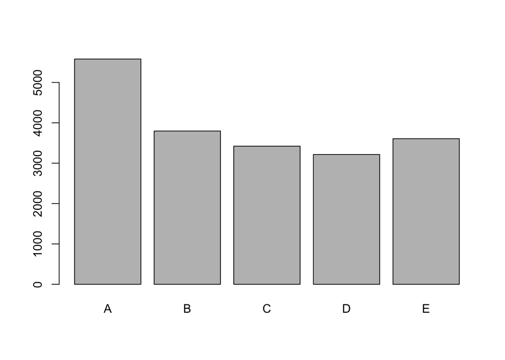

```r
plot(trainingClean$classe)
```

We can see that the A category into class variable, has 5580 observations, follow of the B category with 3797.

## Models building

I will estimate three models. The first one I use the randomForest package, I use the mtry default to obtain the best outcome.

### Model 1

```r
set.seed(10000)
model <- randomForest(classe ~., data = dfTraining)
model
```

```
##
## Call:
##  randomForest(formula = classe ~ ., data = dfTraining)
##                Type of random forest: classification
##                      Number of trees: 500
## No. of variables tried at each split: 7
##
##         OOB estimate of  error rate: 0.3%
## Confusion matrix:
##      A    B    C    D    E  class.error
## A 5578    1    0    0    1 0.0003584229
## B   11 3782    4    0    0 0.0039504872
## C    0    9 3410    3    0 0.0035067212
## D    0    0   22 3192    2 0.0074626866
## E    0    0    1    4 3602 0.0013861935
```

With the first model I obtain a good accuracy, only 0.3% of error rate. But this result will be interpreted carrefully, because despite you could obtain a good accuracy, this method has the cons of overfitting. For this reason I estimate two adittional models to compare and can see if the forecast among three models is different.

### Model 2

For the second model I take a random sample of the training data, and I use this sample to estimate this model. The random sample is of 8000 observations, that is the 40.8% of the original training data.

```r
straining <- sample(nrow(dfTraining), 8000)
trainingFin <- dfTraining[straining, ]
```

```r
set.seed(10000)
model1 <- train(classe ~., data = trainingFin, method = "rf", prox = TRUE, trControl = trainControl(method = "cv", number = 4, allowParallel = TRUE))
model1
```

```
## Random Forest
##
## 8000 samples
##   52 predictor
##    5 classes: 'A', 'B', 'C', 'D', 'E'
##
## No pre-processing
## Resampling: Cross-Validated (4 fold)
##
## Summary of sample sizes: 5999, 5999, 6002, 6000
##
## Resampling results across tuning parameters:
##
##   mtry  Accuracy   Kappa      Accuracy SD  Kappa SD
##    2    0.9813736  0.9764215  0.004825930  0.006112085
##   27    0.9819972  0.9772132  0.005970441  0.007559637
##   52    0.9738716  0.9669275  0.006818357  0.008633773
##
## Accuracy was used to select the optimal model using  the largest value.
## The final value used for the model was mtry = 27.
```

### Model 3

In the last model I spliting the training data tidy into training and testing data. After I make the confusion matrix to estimate out-sample error.

Splitting data:

```r
inTrain <- createDataPartition(y = trainingFin$classe, p = 0.7, list = FALSE)

ptraining = trainingFin[inTrain,]
ptesting = trainingFin[-inTrain,]
```

Estimation model 3:

```r
set.seed(10000)
model2 <- train(classe ~., data = ptraining, method = "rf", prox = TRUE, trControl = trainControl(method = "cv", number = 4, allowParallel = TRUE))
model2
```

```
## Random Forest
##
## 5602 samples
##   52 predictor
##    5 classes: 'A', 'B', 'C', 'D', 'E'
##
## No pre-processing
## Resampling: Cross-Validated (4 fold)
##
## Summary of sample sizes: 4203, 4200, 4201, 4202
##
## Resampling results across tuning parameters:
##
##   mtry  Accuracy   Kappa      Accuracy SD  Kappa SD
##    2    0.9723316  0.9649749  0.001575921  0.001997985
##   27    0.9757229  0.9692709  0.002472381  0.003118905
##   52    0.9687640  0.9604762  0.004938379  0.006243257
##
## Accuracy was used to select the optimal model using  the largest value.
## The final value used for the model was mtry = 27.
```

Finally, I will do predictions and confusion matrix to obtain out-sample error:

```r
predictions <- predict(model2, newdata = ptesting)
confusionMatrix(predictions, ptesting$classe)
```

```
## Confusion Matrix and Statistics
##
##           Reference
## Prediction   A   B   C   D   E
##          A 683  10   0   0   0
##          B   2 440  13   0   0
##          C   0   8 411   7   5
##          D   0   0   2 377   5
##          E   1   0   0   1 433
##
## Overall Statistics
##
##                Accuracy : 0.9775
##                  95% CI : (0.9707, 0.983)
##     No Information Rate : 0.2861
##     P-Value [Acc > NIR] : < 2.2e-16
##
##                   Kappa : 0.9715
##  Mcnemar's Test P-Value : NA
##
## Statistics by Class:
##
##                      Class: A Class: B Class: C Class: D Class: E
## Sensitivity            0.9956   0.9607   0.9648   0.9792   0.9774
## Specificity            0.9942   0.9923   0.9899   0.9965   0.9990
## Pos Pred Value         0.9856   0.9670   0.9536   0.9818   0.9954
## Neg Pred Value         0.9982   0.9907   0.9924   0.9960   0.9949
## Prevalence             0.2861   0.1910   0.1776   0.1606   0.1847
## Detection Rate         0.2848   0.1835   0.1714   0.1572   0.1806
## Detection Prevalence   0.2890   0.1897   0.1797   0.1601   0.1814
## Balanced Accuracy      0.9949   0.9765   0.9773   0.9879   0.9882
```

With te confusion matrix we can see that the out-sample error is low, I obtain a 97.7% of accuracy with 95% CI : (0.9707, 0.983).

The last part is to compare the forecast of the three models to see if there are differences among its:

```r
answers <- predict(model, dfTesting)
answers1 <- predict(model1, dfTesting)
answers2 <- predict(model2, dfTesting)
answers
```

```
##  1  2  3  4  5  6  7  8  9 10 11 12 13 14 15 16 17 18 19 20
##  B  A  B  A  A  E  D  B  A  A  B  C  B  A  E  E  A  B  B  B
## Levels: A B C D E
```

```r
answers1
```

```
##  [1] B A B A A E D B A A B C B A E E A B B B
## Levels: A B C D E
```

```r
answers2
```

```
##  [1] B A B A A E D B A A B C B A E E A B B B
## Levels: A B C D E
```

We can see that the forecast is the same among the different models.

Finally I use the code to suggested in the project course to built to each of the 20 test cases in the testing data set:

```r
pml_write_files = function(x) {
     n = length(x)
     for (i in 1:n) {
         filename = paste0("problem_id_", i, ".txt")
         write.table(x[i], file = filename, quote = FALSE, row.names = FALSE,
             col.names = FALSE)
    }
}

pml_write_files(answers)
```

## Conclusions

Both training and testing data, have a lot variables with NA values, we need clean this data.

The outcome of the model using randomForest must be interpreted carefully, because this model has the cons of overfitting.

With the three models I obtain a good accuracy, above 97%

With cross validation I obtain a good results, 97.7% of accuracy. That’s is the out-sample error is low.

Forecast is the same among the three models.

## References

[1]: L. Breiman. Random forests. *Machine Learning*, pages 5-32, 2001